# Data manipulation - tidyverse : tidyr

ozge.ozdamar@msgsu.edu.tr

MSGSU ISTATISTIK BOLUMU - R ILE ISTATISTIKSEL PROGRAMLAMA DERS NOTLARI by ozge.ozdamar@msgsu.edu.tr is licensed under a [Creative Commons Attribution-NonCommercial-ShareAlike 4.0 International License](http://creativecommons.org/licenses/by-nc-sa/4.0/).

**LIBRARIES**

```r
.packages = c("tidyverse", "hflights", "gapminder")
.inst <- .packages %in% installed.packages()
if(length(.packages[!.inst]) > 0) install.packages(.packages[!.inst])
lapply(.packages, require, character.only=TRUE)
#devtools::install_github("garrettgman/DSR")
```

```r
#library(DSR)
```

**REFERENCES**

[REF1](http://vita.had.co.nz/papers/tidy-data.html)

[REF2](http://garrettgman.github.io/tidying/)

[REF3](https://www.rstudio.com/resources/webinars/data-wrangling-with-r-and-rstudio/)

[REF4](https://tidyr.tidyverse.org)

# 1 tidyverse

The [tidyverse](https://www.tidyverse.org) is a set of packages that work in harmony because they share common data representations and API design. The tidyverse package is designed to make it easy to install and load core packages from the tidyverse in a single command. https://www.tidyverse.org

`library(tidyverse)` will load the core tidyverse packages:

**core packages**

- **ggplot2**, for data visualisation

[figure not shown]

- **dplyr**, for data manipulation

[figure not shown]

- **tidyr**, for data tidying

[figure not shown]

- **readr**, for data import

[figure not shown]

- **purrr**, for functional programming

[figure not shown]

- **tibble**, for tibbles, a modern re-imagining of data frames

[figure not shown]

- **stringr**, for strings

[figure not shown]

- **forcats**, for factors.

[figure not shown]

As well as the core tidyverse, installing this package also installs a selection of other packages that you’re likely to use frequently, but probably not in every analysis. This includes packages for:

Working with specific types of vectors:

- **hms**, for times
- **lubridate**, for date/times

Importing other types of data:

- **feather**, for sharing with Python and other languages
- **haven**, for SPSS, SAS and Stata files
- **httr**, for web apis
- **jsonlite** for JSON
- **readxl**, for .xls and .xlsx files
- **rvest**, for web scraping
- **xml2**, for XML

Modelling

- **modelr**, for modelling within a pipeline
- **broom**, for turning models into tidy data

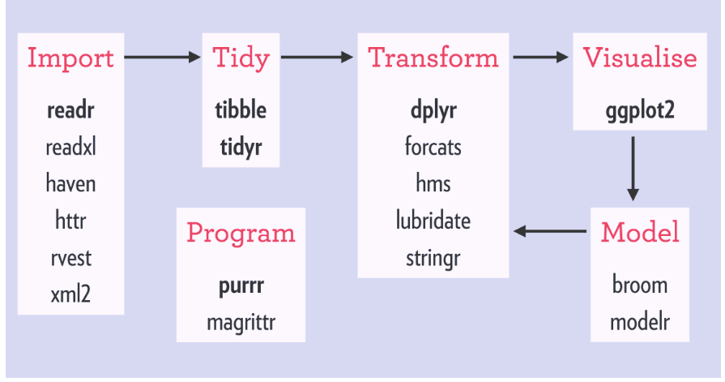

for conflicts of tidyverse:

```r
tidyverse_conflicts()
```

to update tidyverse:

```r
tidyverse_update()
```

# 2 tbl

`tb` -pronounced tibble- or `tbl_df`, is just a special kind of data.frame, making data easier to look at and also easier to work with.

The tbl format changes how R displays data, but it does not change the data’s underlying data structure. A tbl inherits the original class of its input (data.frame).This means that you can still manipulate the tibble as if it were a data.frame.

for tibble reference:

```r
vignette("tibble")
```

and [tb](https://tibble.tidyverse.org)

## 2.1 create tibble

1. `tibble()` function You can create a new tibble from column vectors with `tibble()`:

```r
tb<-tibble(
  x=1:5,
  y=1,
  z= x^2 + y)
tb
```

| x | y | z |
| --- | --- | --- |
| 1 | 1 | 2 |
| 2 | 1 | 5 |
| 3 | 1 | 10 |
| 4 | 1 | 17 |
| 5 | 1 | 26 |

```r
tibble(x=1:5, x^2)
```

| x | x^2 |
| --- | --- |
| 1 | 1 |
| 2 | 4 |
| 3 | 9 |
| 4 | 16 |
| 5 | 25 |

| type |  |
| --- | --- |
| int | integer |
| dbl | double, real number |
| chr | character vector, string |
| date | date |
| dttm | date-time (date+time) |
| lgl | logical |
| fctr | factor |

```r
is.data.frame(tb)
```

```
## [1] TRUE
```

```r
is.tbl(tb)
```

```
## [1] TRUE
```

```r
is.tibble(tb)
```

```
## [1] TRUE
```

```r
class(tb)
```

```
## [1] "tbl_df"     "tbl"        "data.frame"
```

```r
typeof(tb)
```

```
## [1] "list"
```

```r
mode(tb)
```

```
## [1] "list"
```

```r
str(tb)
```

```
## tibble [5 × 3] (S3: tbl_df/tbl/data.frame)
##  $ x: int [1:5] 1 2 3 4 5
##  $ y: num [1:5] 1 1 1 1 1
##  $ z: num [1:5] 2 5 10 17 26
```

2. coercion

```r
as.tibble(iris)
```

| Sepal.Length | Sepal.Width | Petal.Length | Petal.Width | Species |
| --- | --- | --- | --- | --- |
| 5.1 | 3.5 | 1.4 | 0.2 | setosa |
| 4.9 | 3.0 | 1.4 | 0.2 | setosa |
| 4.7 | 3.2 | 1.3 | 0.2 | setosa |
| 4.6 | 3.1 | 1.5 | 0.2 | setosa |
| 5.0 | 3.6 | 1.4 | 0.2 | setosa |
| 5.4 | 3.9 | 1.7 | 0.4 | setosa |
| 4.6 | 3.4 | 1.4 | 0.3 | setosa |
| 5.0 | 3.4 | 1.5 | 0.2 | setosa |
| 4.4 | 2.9 | 1.4 | 0.2 | setosa |
| 4.9 | 3.1 | 1.5 | 0.1 | setosa |

[output cut: 140 more lines]

3. `tribble()` function

`tribble()` is short for transposed tibble,creating a easier to read row-wise tibble, useful for small tables. `tribble()` is customised for data entry in code: column headings are defined by formulas (i.e. they start with ~), and entries are separated by commas. This makes it possible to lay out small amounts of data in easy to read form.

```r
tribble(
  ~x, ~y, ~z,
  "a", 2, 3.6,
  "b", 1, 8.5
)
```

| x | y | z |
| --- | --- | --- |
| a | 2 | 3.6 |
| b | 1 | 8.5 |

`tribble` will create a list column if the value in any cell is not a scalar

```r
 tribble(
  ~x,  ~y,
  "a", 1:3,
  "b", 4:6
)
```

| x | y |
| --- | --- |
| a |  |
| b |  |

4. `enframe()` function

`enframe()`converts named atomic vectors or lists to two-column data frames. For unnamed vectors, the natural sequence is used as name column.

`deframe()` converts two-column data frames to a named vector or list, using the first column as name and the second column as value.

```r
#enframe(x, name = "name", value = "value")
```

```r
enframe(1:3)
```

| name | value |
| --- | --- |
| 1 | 1 |
| 2 | 2 |
| 3 | 3 |

```r
enframe(c(a = 5, b = 7))
```

| name | value |
| --- | --- |
| a | 5 |
| b | 7 |

```r
enframe(list(one = 1, two = 2:3, three = 4:6))
```

| name | value |
| --- | --- |
| one |  |
| two |  |
| three |  |

```r
deframe(enframe(1:3))
```

```
## 1 2 3
## 1 2 3
```

```r
deframe(tibble(a = 1:3))
```

```
## [1] 1 2 3
```

```r
deframe(tibble(a = as.list(1:3)))
```

```
## [[1]]
## [1] 1
##
## [[2]]
## [1] 2
##
## [[3]]
## [1] 3
```

## 2.2 properties of tibble

`tibble()` constructs a data frame. It is used like `base::data.frame()`, but with a couple notable differences:

`tibble()` does much less than `data.frame()`. `tibble()` is a trimmed down version of `data.frame()` that:

1. **Never coerces inputs (i.e. strings stay as strings!).**
2. **Never adds row.names.**
3. **Never munges column names.**
4. **Only recycles length 1 inputs.**
5. **Evaluates its arguments lazily and in order.**
6. **Adds tbl_df class to output.**
7. **Automatically adds column names.**
8. it never changes the type of the inputs (e.g. it never converts strings to factors!),

```r
letters
```

```
##  [1] "a" "b" "c" "d" "e" "f" "g" "h" "i" "j" "k" "l" "m" "n" "o" "p" "q" "r" "s"
## [20] "t" "u" "v" "w" "x" "y" "z"
```

```r
str(data.frame(letters))
```

```
## 'data.frame':    26 obs. of  1 variable:
##  $ letters: chr  "a" "b" "c" "d" ...
```

```r
str(data.frame(letters,stringsAsFactors = FALSE))
```

```
## 'data.frame':    26 obs. of  1 variable:
##  $ letters: chr  "a" "b" "c" "d" ...
```

```r
str(tibble(letters))
```

```
## tibble [26 × 1] (S3: tbl_df/tbl/data.frame)
##  $ letters: chr [1:26] "a" "b" "c" "d" ...
```

2. it never creates row names. It never uses `row.names()`. The whole point of tidy data is to store variables in a consistent way. So it never stores a variable as special attribute.

```r
has_rownames(df)
remove_rownames(df)
rownames_to_column(df, var = "rowname")
rowid_to_column(df, var = "rowid")
column_to_rownames(df, var = "rowname")
```

```r
has_rownames(mtcars)
```

```
## [1] TRUE
```

```r
head(remove_rownames(mtcars))
```

|  | mpg | cyl | disp | hp | drat | wt | qsec | vs | am | gear | carb |
| --- | --- | --- | --- | --- | --- | --- | --- | --- | --- | --- | --- |
| 1 | 21.0 | 6 | 160 | 110 | 3.90 | 2.620 | 16.46 | 0 | 1 | 4 | 4 |
| 2 | 21.0 | 6 | 160 | 110 | 3.90 | 2.875 | 17.02 | 0 | 1 | 4 | 4 |
| 3 | 22.8 | 4 | 108 | 93 | 3.85 | 2.320 | 18.61 | 1 | 1 | 4 | 1 |
| 4 | 21.4 | 6 | 258 | 110 | 3.08 | 3.215 | 19.44 | 1 | 0 | 3 | 1 |
| 5 | 18.7 | 8 | 360 | 175 | 3.15 | 3.440 | 17.02 | 0 | 0 | 3 | 2 |
| 6 | 18.1 | 6 | 225 | 105 | 2.76 | 3.460 | 20.22 | 1 | 0 | 3 | 1 |

```r
head(rownames_to_column(mtcars))
```

|  | rowname | mpg | cyl | disp | hp | drat | wt | qsec | vs | am | gear | carb |
| --- | --- | --- | --- | --- | --- | --- | --- | --- | --- | --- | --- | --- |
| 1 | Mazda RX4 | 21.0 | 6 | 160 | 110 | 3.90 | 2.620 | 16.46 | 0 | 1 | 4 | 4 |
| 2 | Mazda RX4 Wag | 21.0 | 6 | 160 | 110 | 3.90 | 2.875 | 17.02 | 0 | 1 | 4 | 4 |
| 3 | Datsun 710 | 22.8 | 4 | 108 | 93 | 3.85 | 2.320 | 18.61 | 1 | 1 | 4 | 1 |
| 4 | Hornet 4 Drive | 21.4 | 6 | 258 | 110 | 3.08 | 3.215 | 19.44 | 1 | 0 | 3 | 1 |
| 5 | Hornet Sportabout | 18.7 | 8 | 360 | 175 | 3.15 | 3.440 | 17.02 | 0 | 0 | 3 | 2 |
| 6 | Valiant | 18.1 | 6 | 225 | 105 | 2.76 | 3.460 | 20.22 | 1 | 0 | 3 | 1 |

```r
mtcars_tbl <- as_tibble(rownames_to_column(mtcars))
mtcars_tbl
```

| rowname | mpg | cyl | disp | hp | drat | wt | qsec | vs | am | gear | carb |
| --- | --- | --- | --- | --- | --- | --- | --- | --- | --- | --- | --- |
| Mazda RX4 | 21.0 | 6 | 160.0 | 110 | 3.90 | 2.620 | 16.46 | 0 | 1 | 4 | 4 |
| Mazda RX4 Wag | 21.0 | 6 | 160.0 | 110 | 3.90 | 2.875 | 17.02 | 0 | 1 | 4 | 4 |
| Datsun 710 | 22.8 | 4 | 108.0 | 93 | 3.85 | 2.320 | 18.61 | 1 | 1 | 4 | 1 |
| Hornet 4 Drive | 21.4 | 6 | 258.0 | 110 | 3.08 | 3.215 | 19.44 | 1 | 0 | 3 | 1 |
| Hornet Sportabout | 18.7 | 8 | 360.0 | 175 | 3.15 | 3.440 | 17.02 | 0 | 0 | 3 | 2 |
| Valiant | 18.1 | 6 | 225.0 | 105 | 2.76 | 3.460 | 20.22 | 1 | 0 | 3 | 1 |
| Duster 360 | 14.3 | 8 | 360.0 | 245 | 3.21 | 3.570 | 15.84 | 0 | 0 | 3 | 4 |
| Merc 240D | 24.4 | 4 | 146.7 | 62 | 3.69 | 3.190 | 20.00 | 1 | 0 | 4 | 2 |
| Merc 230 | 22.8 | 4 | 140.8 | 95 | 3.92 | 3.150 | 22.90 | 1 | 0 | 4 | 2 |
| Merc 280 | 19.2 | 6 | 167.6 | 123 | 3.92 | 3.440 | 18.30 | 1 | 0 | 4 | 4 |

[output cut: 22 more lines]

```r
column_to_rownames(as.data.frame(mtcars_tbl))
```

|  | mpg | cyl | disp | hp | drat | wt | qsec | vs | am | gear | carb |
| --- | --- | --- | --- | --- | --- | --- | --- | --- | --- | --- | --- |
| Mazda RX4 | 21.0 | 6 | 160.0 | 110 | 3.90 | 2.620 | 16.46 | 0 | 1 | 4 | 4 |
| Mazda RX4 Wag | 21.0 | 6 | 160.0 | 110 | 3.90 | 2.875 | 17.02 | 0 | 1 | 4 | 4 |
| Datsun 710 | 22.8 | 4 | 108.0 | 93 | 3.85 | 2.320 | 18.61 | 1 | 1 | 4 | 1 |
| Hornet 4 Drive | 21.4 | 6 | 258.0 | 110 | 3.08 | 3.215 | 19.44 | 1 | 0 | 3 | 1 |
| Hornet Sportabout | 18.7 | 8 | 360.0 | 175 | 3.15 | 3.440 | 17.02 | 0 | 0 | 3 | 2 |
| Valiant | 18.1 | 6 | 225.0 | 105 | 2.76 | 3.460 | 20.22 | 1 | 0 | 3 | 1 |
| Duster 360 | 14.3 | 8 | 360.0 | 245 | 3.21 | 3.570 | 15.84 | 0 | 0 | 3 | 4 |
| Merc 240D | 24.4 | 4 | 146.7 | 62 | 3.69 | 3.190 | 20.00 | 1 | 0 | 4 | 2 |
| Merc 230 | 22.8 | 4 | 140.8 | 95 | 3.92 | 3.150 | 22.90 | 1 | 0 | 4 | 2 |
| Merc 280 | 19.2 | 6 | 167.6 | 123 | 3.92 | 3.440 | 18.30 | 1 | 0 | 4 | 4 |

[output cut: 22 more lines]

- It only recycles vectors of length 1. This is because recycling vectors of greater lengths is a frequent source of bugs.

It’s possible for a tibble to have column names that are not valid R variable names, aka non-syntactic names. For example, they might not start with a letter, or they might contain unusual characters like a space

```r
tb <- tibble(
  `:)` = "smile",
  ` ` = "space",
  `2000` = "number"
)
tb
```

| :) |  | 2000 |
| --- | --- | --- |
| smile | space | number |

Tibble makes it easier to use with list-columns:

```r
tibble(x = 1:3, y = list(1:5, 1:10, 1:20))
```

| x | y |
| --- | --- |
| 1 |  |
| 2 |  |
| 3 |  |

List-columns are most commonly created by `do()`, but they can be useful to create by hand.

## 2.3 tibble vs data.frame

There are three key differences between tibbles and data frames: printing, subsetting, and recycling rules.

### 2.3.1 printing

When you print a tibble, it only shows the first ten rows and all the columns that fit on one screen. It also prints an abbreviated description of the column type:

```r
tibble(x = 1:1000)
```

| x |
| --- |
| 1 |
| 2 |
| 3 |
| 4 |
| 5 |
| 6 |
| 7 |
| 8 |
| 9 |
| 10 |

[output cut: 990 more lines]

You can control the default appearance with options:

```r
tibble(x = 1:1000)
options(tibble.print_max = 20, tibble.print_min = 3)
```

if there are more than n rows, print only the first m rows. Use

```r
options(tibble.print_max = Inf)
```

to always show all rows.

```r
options(tibble.width = Inf)
```

will always print all columns, regardless of the width of the screen.

### 2.3.2 subsetting

Tibbles are quite strict about subsetting. [ always returns another tibble. Contrast this with a data frame: sometimes [ returns a data frame and sometimes it just returns a vector:

```r
df1 <- data.frame(x = 1:3, y = 3:1)
class(df1[, 1:2])
```

```
## [1] "data.frame"
```

```r
class(df1[, 1])
```

```
## [1] "integer"
```

```r
df2 <- tibble(x = 1:3, y = 3:1)
class(df2[, 1:2])
```

```
## [1] "tbl_df"     "tbl"        "data.frame"
```

```r
class(df2[, 1])
```

```
## [1] "tbl_df"     "tbl"        "data.frame"
```

To extract a single column use [[ or $:

```r
class(df2[[1]])
```

```
## [1] "integer"
```

```r
class(df2$x)
```

```
## [1] "integer"
```

Tibbles are also stricter with $. Tibbles never do partial matching, and will throw a warning and return NULL if the column does not exist:

```r
df <- data.frame(abc = 1)
df$a
```

```
## [1] 1
```

```r
df2 <- tibble(abc = 1)
df2$a
```

```
## Warning: Unknown or uninitialised column: `a`.
```

As of version 1.4.1, tibbles no longer ignore the drop argument:

```r
data.frame(a = 1:3)[, "a", drop = TRUE]
```

```
## [1] 1 2 3
```

```r
tibble(a = 1:3)[, "a", drop = TRUE]
```

```
## [1] 1 2 3
```

### 2.3.3 Recycling

When constructing a tibble, only values of length 1 are recycled. The first column with length different to one determines the number of rows in the tibble, conflicts lead to an error. This also extends to tibbles with zero rows, which is sometimes important for programming:

```r
tibble(a = 1, b = 1:3)
```

| a | b |
| --- | --- |
| 1 | 1 |
| 1 | 2 |
| 1 | 3 |

```r
tibble(a = 1:3, b = 1)
```

| a | b |
| --- | --- |
| 1 | 1 |
| 2 | 1 |
| 3 | 1 |

```r
# tibble(a = 1:3, c = 1:2)
tibble(a = 1, b = integer())
```

| a | b |
| --- | --- |

```r
tibble(a = integer(), b = 1)
```

| a | b |
| --- | --- |

exercise

```r
annoying <- tibble(
  `1` = 1:10,
  `2` = `1` * 2 + rnorm(length(`1`))
)
```

Extracting the variable called 1.

```r
annoying[["1"]]
```

```
##  [1]  1  2  3  4  5  6  7  8  9 10
```

```r
annoying$`1`
```

```
##  [1]  1  2  3  4  5  6  7  8  9 10
```

Creating a new column called 3 which is 2 divided by 1.

```r
annoying[["3"]] <- annoying$`2` / annoying$`1`
annoying[["3"]] <- annoying[["2"]] / annoying[["1"]]
```

Renaming the columns to one, two and three

```r
annoying <- rename(annoying, one = `1`, two = `2`, three = `3`)
glimpse(annoying)
```

```
## Rows: 10
## Columns: 3
## $ one   <int> 1, 2, 3, 4, 5, 6, 7, 8, 9, 10
## $ two   <dbl> 1.682470, 2.937045, 6.487889, 8.814086, 9.713875, 11.929122, 14.…
## $ three <dbl> 1.682470, 1.468523, 2.162630, 2.203521, 1.942775, 1.988187, 2.06…
```

The function tibble::enframe() converts named vectors to a data frame with names and values

```r
enframe(c(a = 1, b = 2, c = 3))
```

| name | value |
| --- | --- |
| a | 1 |
| b | 2 |
| c | 3 |

inspect data.frame vs tb

```r
df <- data.frame(abc = 1, xyz = "a")
df$x
```

```
## [1] "a"
```

```r
df[, "xyz"]
```

```
## [1] "a"
```

```r
df[, c("abc", "xyz")]
```

| abc | xyz |
| --- | --- |
| 1 | a |

```r
tbl <- as_tibble(df)
tbl$x
```

```r
tbl[, "xyz"]
```

| xyz |
| --- |
| a |

```r
tbl[, c("abc", "xyz")]
```

| abc | xyz |
| --- | --- |
| 1 | a |

# 3 tidy data

Table 1: typical presentation dataset

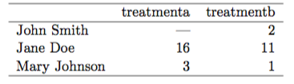

Table 2: the same data as in Table 1 but structured differently

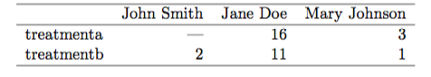

Table3: The sama data as in Table 1 but with variables in columns and observations in rows

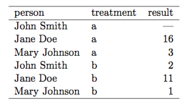

Table 3 is the tidy version of Table 1. Each row represents an observation, the result of one treatment on one person, and each column is a variable.

A dataset is messy or tidy depending on how rows, columns and tables are matched up with observations, variables and types. In tidy data: 1. Each variable forms a column. 2. Each observation forms a row. 3. Each type of observational unit forms a table.

This is Codd’s 3rd normal form (Codd 1990), but with the constraints framed in statistical language, and the focus put on a single dataset rather than the many connected datasets common in relational databases. Messy data is any other arrangement of the data.

- Column headers are values, not variable names.
- Multiple variables are stored in one column.
- Variables are stored in both rows and columns.
- Multiple types of observational units are stored in the same table.
- A single observational unit is stored in multiple tables.

[tidyr](https://tidyr.tidyverse.org)

Each data set shows the same values of four variables country, year, population, and cases, but each data set organizes the values into a different layout

## 3.1 sampe datasets

### 3.1.1 table1

In `table1` each row is a (country, year) with variables `cases` and `population`.

```r
table1
```

| country | year | cases | population |
| --- | --- | --- | --- |
| Afghanistan | 1999 | 745 | 19987071 |
| Afghanistan | 2000 | 2666 | 20595360 |
| Brazil | 1999 | 37737 | 172006362 |
| Brazil | 2000 | 80488 | 174504898 |
| China | 1999 | 212258 | 1272915272 |
| China | 2000 | 213766 | 1280428583 |

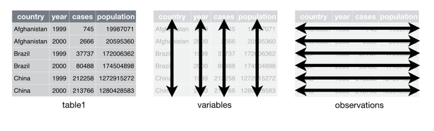

### 3.1.2 table2

In `table2`, each row is country, year , variable (“cases”, “population”) combination, and there is a `count` variable with the numeric value of the combination.

```r
table2
```

| country | year | type | count |
| --- | --- | --- | --- |
| Afghanistan | 1999 | cases | 745 |
| Afghanistan | 1999 | population | 19987071 |
| Afghanistan | 2000 | cases | 2666 |
| Afghanistan | 2000 | population | 20595360 |
| Brazil | 1999 | cases | 37737 |
| Brazil | 1999 | population | 172006362 |
| Brazil | 2000 | cases | 80488 |
| Brazil | 2000 | population | 174504898 |
| China | 1999 | cases | 212258 |
| China | 1999 | population | 1272915272 |

[output cut: 2 more lines]

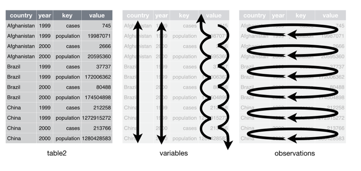

### 3.1.3 table3

```r
table3
```

| country | year | rate |
| --- | --- | --- |
| Afghanistan | 1999 | 745/19987071 |
| Afghanistan | 2000 | 2666/20595360 |
| Brazil | 1999 | 37737/172006362 |
| Brazil | 2000 | 80488/174504898 |
| China | 1999 | 212258/1272915272 |
| China | 2000 | 213766/1280428583 |

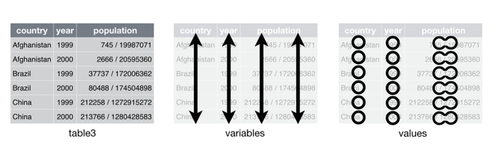

### 3.1.4 table4

Table 4 is split into two tables, one table for each variable: `table4a` is the table for cases, while `table4b` is the table for population. Within each table, each row is a country, each column is a year, and the cells are the value of the variable for the table.

```r
table4a
```

| country | 1999 | 2000 |
| --- | --- | --- |
| Afghanistan | 745 | 2666 |
| Brazil | 37737 | 80488 |
| China | 212258 | 213766 |

```r
table4b
```

| country | 1999 | 2000 |
| --- | --- | --- |
| Afghanistan | 19987071 | 20595360 |
| Brazil | 172006362 | 174504898 |
| China | 1272915272 | 1280428583 |

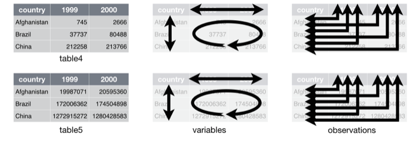

## 3.2 tidy data

- Each variable is saved in its own column.
- Each observation is saved in its own row.
- Each “type” of observation stored in a single table

tdying

| function |  |
| --- | --- |
| `extract()` | Extract one column into multiple columns. |
| `gather()` | Gather columns into key-value pairs |
| `nest()` | Nest repeated values in a list-variable. |
| `separate()` | Separate one column into multiple columns. |
| `separate_rows()` | Separate a collapsed column into multiple rows. |
| `spread()` | Spread a key-value pair across multiple columns. |
| `unite()` | Unite multiple columns into one. |
| `unnest()` | Unnest a list column |

NA

| function |  |
| --- | --- |
| `complete()` | Complete a data frame with missing combinations of data. |
| `drop_na()` | Drop rows containing missing values |
| `expand() crossing() nesting()` | Expand data frame to include all combinations of values |
| `fill()` | Fill in missing values. |
| `full_seq()` | Create the full sequence of values in a vector. |
| `replace_na()` | Replace missing values |
| `uncount()` | “Uncount” a data frame |

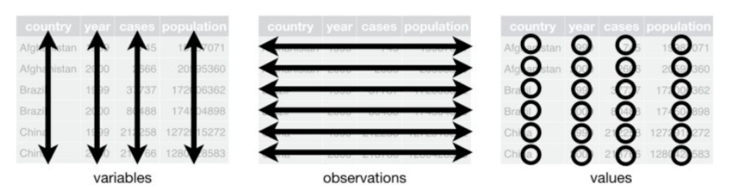

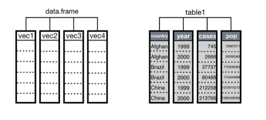

# 4 pipe operator

Ctrl + Shift + M (Windows), Cmd + Shift + M (Mac).

The pipe operator takes the thing on the left-hand-side and pipes it into

the function call on the right-hand-side ??? literally, drops it in as the first argument.

```r
library(gapminder)
head(gapminder)
```

| country | continent | year | lifeExp | pop | gdpPercap |
| --- | --- | --- | --- | --- | --- |
| Afghanistan | Asia | 1952 | 28.801 | 8425333 | 779.4453 |
| Afghanistan | Asia | 1957 | 30.332 | 9240934 | 820.8530 |
| Afghanistan | Asia | 1962 | 31.997 | 10267083 | 853.1007 |
| Afghanistan | Asia | 1967 | 34.020 | 11537966 | 836.1971 |
| Afghanistan | Asia | 1972 | 36.088 | 13079460 | 739.9811 |
| Afghanistan | Asia | 1977 | 38.438 | 14880372 | 786.1134 |

```r
gapminder %>% head()
```

| country | continent | year | lifeExp | pop | gdpPercap |
| --- | --- | --- | --- | --- | --- |
| Afghanistan | Asia | 1952 | 28.801 | 8425333 | 779.4453 |
| Afghanistan | Asia | 1957 | 30.332 | 9240934 | 820.8530 |
| Afghanistan | Asia | 1962 | 31.997 | 10267083 | 853.1007 |
| Afghanistan | Asia | 1967 | 34.020 | 11537966 | 836.1971 |
| Afghanistan | Asia | 1972 | 36.088 | 13079460 | 739.9811 |
| Afghanistan | Asia | 1977 | 38.438 | 14880372 | 786.1134 |

```r
select(gapminder, year, lifeExp)
```

| year | lifeExp |
| --- | --- |
| 1952 | 28.80100 |
| 1957 | 30.33200 |
| 1962 | 31.99700 |
| 1967 | 34.02000 |
| 1972 | 36.08800 |
| 1977 | 38.43800 |
| 1982 | 39.85400 |
| 1987 | 40.82200 |
| 1992 | 41.67400 |
| 1997 | 41.76300 |

[output cut: 1694 more lines]

```r
gapminder %>%
  select(year, lifeExp) %>%
  head(4)
```

| year | lifeExp |
| --- | --- |
| 1952 | 28.801 |
| 1957 | 30.332 |
| 1962 | 31.997 |
| 1967 | 34.020 |

# 5 tydying data

## 5.1 `gather()`

Gather takes multiple columns and collapses into key-value pairs, duplicating all other columns as needed. You use `gather()` when you notice that you have columns that are not variables. It produces a “long” data format from a “wide” one. It’s an alternative of `melt()` function [in `reshape2` package].

```r
gather(data, key = "key", value = "value", ..., na.rm = FALSE,
  convert = FALSE, factor_key = FALSE)

data: a data frame
key_col, value_col: Strings specifying the names of key and value columns to create
gather_cols: Character vector specifying column names to be gathered together into pair of key-value columns.
```

make the data set a tibble

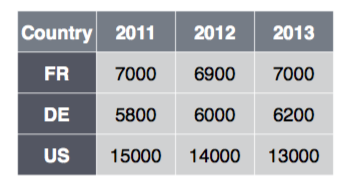

```r
cases<-tibble(country=c("FR","D","US"),
      '2011'=c(7000,5800,15000),
      '2012'=c(6900,6000,14000),
      '2013'=c(7000,6200,13000)
)
cases
```

| country | 2011 | 2012 | 2013 |
| --- | --- | --- | --- |
| FR | 7000 | 6900 | 7000 |
| D | 5800 | 6000 | 6200 |
| US | 15000 | 14000 | 13000 |

```r
gather(cases,"year","n",2:4)
```

| country | year | n |
| --- | --- | --- |
| FR | 2011 | 7000 |
| D | 2011 | 5800 |
| US | 2011 | 15000 |
| FR | 2012 | 6900 |
| D | 2012 | 6000 |
| US | 2012 | 14000 |
| FR | 2013 | 7000 |
| D | 2013 | 6200 |
| US | 2013 | 13000 |

[figure not shown]

```r
table4a
```

| country | 1999 | 2000 |
| --- | --- | --- |
| Afghanistan | 745 | 2666 |
| Brazil | 37737 | 80488 |
| China | 212258 | 213766 |

```r
gather(table4a,'1999', '2000', key="year",value = "cases")
```

| country | year | cases |
| --- | --- | --- |
| Afghanistan | 1999 | 745 |
| Brazil | 1999 | 37737 |
| China | 1999 | 212258 |
| Afghanistan | 2000 | 2666 |
| Brazil | 2000 | 80488 |
| China | 2000 | 213766 |

```r
#or
tidy4a <- table4a %>%
  gather(`1999`, `2000`, key = "year", value = "cases")
tidy4a
```

| country | year | cases |
| --- | --- | --- |
| Afghanistan | 1999 | 745 |
| Brazil | 1999 | 37737 |
| China | 1999 | 212258 |
| Afghanistan | 2000 | 2666 |
| Brazil | 2000 | 80488 |
| China | 2000 | 213766 |

```r
tidy4b <- table4b %>%
  gather(`1999`, `2000`, key = "year", value = "cases")
tidy4b
```

| country | year | cases |
| --- | --- | --- |
| Afghanistan | 1999 | 19987071 |
| Brazil | 1999 | 172006362 |
| China | 1999 | 1272915272 |
| Afghanistan | 2000 | 20595360 |
| Brazil | 2000 | 174504898 |
| China | 2000 | 1280428583 |

Spread a key-value pair across multiple columns.

```r
spread(data, key, value, fill = NA, convert = FALSE, drop = TRUE,
  sep = NULL)
```

**data:** the data **key:** the column variable whose values will become new column names **value:** the column variable whose values will fill the new column variables.

```r
table2
```

| country | year | type | count |
| --- | --- | --- | --- |
| Afghanistan | 1999 | cases | 745 |
| Afghanistan | 1999 | population | 19987071 |
| Afghanistan | 2000 | cases | 2666 |
| Afghanistan | 2000 | population | 20595360 |
| Brazil | 1999 | cases | 37737 |
| Brazil | 1999 | population | 172006362 |
| Brazil | 2000 | cases | 80488 |
| Brazil | 2000 | population | 174504898 |
| China | 1999 | cases | 212258 |
| China | 1999 | population | 1272915272 |

[output cut: 2 more lines]

```r
#spread(data=table2, key = type, value = count)
```

make the data set a tibble

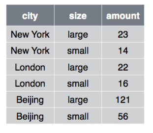

```r
pollution<-tibble(
             city=rep(c("New York","London","Beijing"),each=2),
             size=rep(c("large","small"),3),
             amount=c(23,14,22,16,121,56)
             )
pollution
```

| city | size | amount |
| --- | --- | --- |
| New York | large | 23 |
| New York | small | 14 |
| London | large | 22 |
| London | small | 16 |
| Beijing | large | 121 |
| Beijing | small | 56 |

```r
spread(pollution, size, amount)
```

| city | large | small |
| --- | --- | --- |
| Beijing | 121 | 56 |
| London | 22 | 16 |
| New York | 23 | 14 |

[figure not shown]

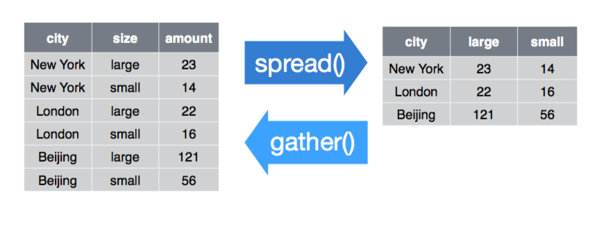

Why are `gather()` and `spread()` not perfectly symmetrical? Carefully consider the following example:

```r
stocks <- tibble(
  year   = c(2015, 2015, 2016, 2016),
  half  = c(   1,    2,     1,    2),
  return = c(1.88, 0.59, 0.92, 0.17)
)
stocks %>%
  spread(year, return) %>%
  gather(`2015`:`2016`, key = "year", value = "return")
```

| half | year | return |
| --- | --- | --- |
| 1 | 2015 | 1.88 |
| 2 | 2015 | 0.59 |
| 1 | 2016 | 0.92 |
| 2 | 2016 | 0.17 |

The functions `spread()` and `gather()` are not perfectly symmetrical because column type information is not transferred between them. When we use `gather()` on a data frame, it throws away all the information about the original column types.

Additionally, it has to coerce all the variables that are being gathered into a single type, since they are going into a single vector. Later if we `spread()` that data frame, the `spread()` function has no way to know what the original data types of the columns that were earlier gathered.

In this example, in the original table, the column `year` was numeric. After running `spread()` and `gather()` it is a character vector. Variable names are always converted to a character vector by `gather()`.

The functions `spread()` and `gather()` can be closer to symmetrical if we use the `convert` argument. It will try to convert character vectors to the appropriate type using `type.convert()`.

```r
stocks %>%
  spread(key = "year", value = "return") %>%
  gather(`2015`:`2016`, key = "year", value = "return", convert = TRUE)
```

| half | year | return |
| --- | --- | --- |
| 1 | 2015 | 1.88 |
| 2 | 2015 | 0.59 |
| 1 | 2016 | 0.92 |
| 2 | 2016 | 0.17 |

However, since `convert = TRUE` is guessing the appropriate type it still may not work.

Why does this code fail?

```r
table4a %>%
  gather(1999, 2000, key = "year", value = "cases")
```

```
## Error in `gather()`:
## ! Can't subset columns past the end.
## ℹ Locations 1999 and 2000 don't exist.
## ℹ There are only 3 columns.
```

The code fails because the column names `1999` and `2000` are not standard and thus needs to be quoted. The tidyverse functions will interpret `1999` and `2000` without quotes as looking for the 1999th and 2000th column of the data frame. This will work:

```r
table4a %>%
  gather(`1999`, `2000`, key = "year", value = "cases")
```

| country | year | cases |
| --- | --- | --- |
| Afghanistan | 1999 | 745 |
| Brazil | 1999 | 37737 |
| China | 1999 | 212258 |
| Afghanistan | 2000 | 2666 |
| Brazil | 2000 | 80488 |
| China | 2000 | 213766 |

Why does spreading this tibble fail? How could you add a new column to fix the problem?

```r
#people <- tribble(
#  ~name,             ~key,    ~value,
  #-----------------|--------|------
#  "Phillip Woods",   "age",       45,
#  "Phillip Woods",   "height",   186,
#  "Phillip Woods",   "age",       50,
#  "Jessica Cordero", "age",       37,
#  "Jessica Cordero", "height",   156
#)
#glimpse(people)
```

```r
#spread(people, key, value)
```

Spreading the data frame fails because there are two rows with “age” for “Phillip Woods”. If we added another column with an indicator for the number observation it is, the code will work.

```r
#people <- tribble(
#  ~name,             ~key,    ~value, ~obs,
  #-----------------|--------|------|------
#  "Phillip Woods",   "age",       45, 1,
#  "Phillip Woods",   "height",   186, 1,
#  "Phillip Woods",   "age",       50, 2,
#  "Jessica Cordero", "age",       37, 1,
#  "Jessica Cordero", "height",   156, 1
#)
#spread(people, key, value)
```

Tidy the simple tibble below. Do you need to spread or gather it? What are the variables?

```r
#preg <- tribble(
#  ~pregnant, ~male, ~female,
#  "yes",     NA,    10,
#  "no",      20,    12
#)
```

To tidy `preg`, we need to use `gather()`. The variables in this data are

- `sex` (“female”, “male”)
- `pregnant` (“yes”, “no”)
- `count`, which is a non-negative integer representing the number of observations.

The observations in this data are unique combinations of sex and pregnancy status.

```r
#preg_tidy <- preg %>%
#  gather(male, female, key = "sex", value = "count")
#preg_tidy
```

However, we should consider the missing value in the male, non-pregnant row. Is it missing due to missing data, or missing due to structural reasons? This will be discussed in the upcoming section on [Missing Values](http://r4ds.had.co.nz/tidy-data.html#missing-values-3). Supposing that these data represent observations from a species in which it is impossible for males to get pregnant (not seahorses), then that missing value is structural. In the non-tidy data frame we had to include that structural missing value explicitly with an `NA` entry. However, in the tidy version we can drop that row since it is an impossible combination. We can do that by adding the argument `na.rm = TRUE` to `gather()`.

```r
#preg_tidy2 <- preg %>%
#  gather(male, female, key = "sex", value = "count", na.rm = TRUE)
#preg_tidy2
```

Though not necessary, there is one more way in which we can improve this data. If a variable takes two values, like `pregnant` and `sex` do, it is often preferable to store them as logical vectors. The following vector uses logical vectors to represent pregnancy and sex.

```r
#preg_tidy3 <- preg_tidy2 %>%
#  mutate(female = sex == "female",       pregnant = pregnant == "yes") %>%  select(female, pregnant, count)
#preg_tidy3
```

In the previous data frame, I named the logical variable representing the sex `female`, not `sex`. This makes the meaning of the variable self-documenting. If the variable were named `sex` with values `TRUE` and `FALSE`, without reading the documentation, we wouldn’t know whether `TRUE` means male or female.

Apart from some minor memory savings, representing these variables as logical vectors results in more clear and concise code.

```r
#filter(preg_tidy2, sex == "female", pregnant == "no")
#filter(preg_tidy3, female, !pregnant)
```

## 5.2 `separate()`

Given either regular expression or a vector of character positions, `separate()` turns a single character column into multiple columns.

```r
#separate(data, col, into, sep = "[^[:alnum:]]+", remove = TRUE, convert = FALSE, extra = "warn", fill = "warn", ...)
```

```r
#table3
#separate(table3,rate,c("x1","x2"))
```

```r
#newtable<-separate(table3, year, into = c("century", "year"), sep = 2)
#newtable
```

You can futher customize `separate()` with the `remove`, `convert`, and `extra` arguments:

inspect

```r
#tibble(x = c("a,b,c", "d,e,f,g", "h,i,j")) %>%  separate(x, c("one", "two", "three"))
```

```r
#tibble(x = c("a,b,c", "d,e", "f,g,i")) %>% separate(x, c("one", "two", "three"))
```

The `extra` argument tells `separate()` what to do if there are too many pieces, and the `fill` argument if there aren’t enough. By default, `separate()` drops the extra values with a warning.

```r
#tibble(x = c("a,b,c", "d,e,f,g", "h,i,j")) %>% separate(x, c("one", "two", "three"))
```

`extra = "drop"` produces the same result as above, dropping extra values, but without the warning.

```r
#tibble(x = c("a,b,c", "d,e,f,g", "h,i,j")) %>% separate(x, c("one", "two", "three"), extra = "drop")
```

Another option for `extra` is `"merge"`, then the extra values are not split, so `"f,g"` appears in column three.

```r
#tibble(x = c("a,b,c", "d,e,f,g", "h,i,j")) %>%separate(x, c("one", "two", "three"), extra = "merge")
```

In this, one of the entries for column, `"d,e"`, has too few elements. The default for `fill` is similar to those in separate `separate()`; it fills with missing values but emits a warning. In this, row 2 of column `three` is `NA`.

```r
#tibble(x = c("a,b,c", "d,e", "f,g,i")) %>% separate(x, c("one", "two", "three"))
```

Alternative options for `fill` are `"right"`, to fill with missing values from the right, but without a warning

```r
#tibble(x = c("a,b,c", "d,e", "f,g,i")) %>%separate(x, c("one", "two", "three"), fill = "right")
```

The option `fill = "left"` also fills with missing values without a warning, but this time from the left side. Now, row 2 of column `one` will be missing, and the other values in that row are shifted over.

```r
#tibble(x = c("a,b,c", "d,e", "f,g,i")) %>% separate(x, c("one", "two", "three"), fill = "left")
```

## 5.3 `unite()`

Convenience function to paste together multiple columns into one.

```r
#unite(data, col, ..., sep = "_", remove = TRUE)
```

```r
#unite(newtable, "yıl",century, year, sep="")
```

`unite()` returns a copy of the data frame that includes the new column, but not the columns used to build the new column. If you would like to retain these columns, add the argument `remove = FALSE`.

```r
#unite(newtable, "yıl",century, year, sep="", remove = FALSE)
```

**exercise** 1. open `DSR::who` dataset 2. view dataset 3. variable names are coded:

- `rel` stands for cases of relapse
- `ep` stands for cases of extrapulmonary TB
- `sn` stands for cases of pulmonary TB that could not be diagnosed by a pulmonary smear (smear negative)
- `sp` stands for cases of pulmonary TB that could be diagnosed be a pulmonary smear (smear positive)
- The sixth letter describes the sex of TB patients. The data set groups cases by males (m) and females (f).
- The remaining numbers describe the age group of TB patients. The data set groups cases into seven age groups:

** 014 stands for patients that are 0 to 14 years old

** 1524 stands for patients that are 15 to 24 years old

** 2534 stands for patients that are 25 to 34 years old

** 3544 stands for patients that are 35 to 44 years old

** 4554 stands for patients that are 45 to 54 years old

** 5564 stands for patients that are 55 to 64 years old

** 65 stands for patients that are 65 years old or older

`who` data set is untidy in multiple ways. First, the data appears to contain values in its column names. We can move the values into their own column with `gather()`

```r
#who <- gather(who, "code", "value", 5:60)
```

```r
#who <- separate(who, code, c("new", "var", "sexage"))
```

split `sexage` after the first character to create a sex column and an age column.

```r
#who <- separate(who, sexage, c("sex", "age"), sep = 1)
```

move the rel, ep, sn, and sp keys into their own column names with `spread()`.

```r
#who <- spread(who, var, value)
```

The `who` data set is now tidy.